# CS498PS Audio Digital Lab

# Lab 6: Denoising

### by Ching-Hua Yu (cyu17)

In this lab we will use denoising to clean up some noisy recordings. We will use the following sounds:

Speech in a room: [https://drive.google.com/uc?export=download&id=1g5nbBpNbCjqs8cSoW0Lb-owe15tswDwW ]

ATC: [https://drive.google.com/uc?export=download&id=1fh5iL5qRj3-PUP_sG5-QE5DofACY_Hr5 ]

Speech with wind: [https://drive.google.com/uc?export=download&id=1g7TIkLpnWDFNUQYgCqIUoSOkk5EIK16_ ]

First, use stft, draw, readData, saveData from Lab1. In draw, to avoid np.log zero problem, the input magnitude is set to a minimum 1. Also, we will use scipy.signal.medfilt2d as suggested in the Lab6 description. [Update] It turns out wind-speech.wav using chunks and wave doesn't work out. For the file, scipy.io.wavfile is used instead.

## Part 1. Cleaning up the sounds

Let’s start by cleaning up these sounds as best as we can. We will do a straightforward magnitude spectral subtraction. For all of these sounds there is only noise in the first few seconds of the recording so that you can learn a noise profile from there. Do the following: Perform an STFT of the recordings

- Estimate the magnitude spectrum of the noise from the beginning of the recording
  - It’s up to you to figure out how many seconds to use (hint: look at the spectrogram)
- Perform spectral subtraction by subtracting that spectrum from the input’s magnitude STFT
  - Remember to clip any resulting negative values to zero
  - Try to find how much of the noise to subtract so that the output looks good
- Use the original signal’s phase to convert back to a time series.

Make a note of which examples sound the best and are easier to work with. Try to explain why. At this point some of the outputs will exhibit “musical noise”. To minimize its effects apply a median filter on the denoised magnitude spectrogram to make it sound better (hint: `scipy.signal.medfilt2`). How big should the median window be? Try different values and find which work best.

Great! Let's test the first wav file and observe the range of noise in the beginning.

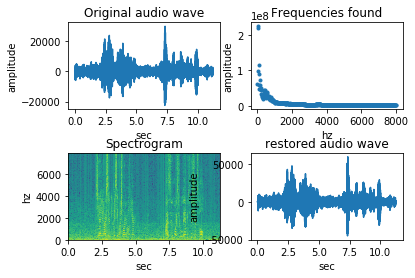

[interactive chart not shown]

Frome the spectrogram above, the beginning noise is essentially within the first 2 sec. Take max of the sampled noise: Obserbe that noise itself has a shift with time. Because we apply a simple subtraction of noise in each time slot on the spectrogram matrix, the denoising effect should be more accurate when the magnitude of centern noise frequency (span) is taken the maximum (rather than average or an empirical scaling).

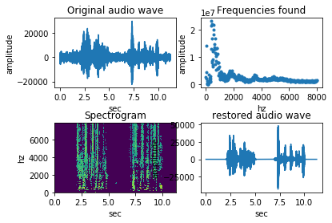

[interactive chart not shown]

Using median filter to reduce "musical noise"

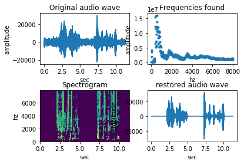

[interactive chart not shown]

Then we test aircomm.wav similarly.

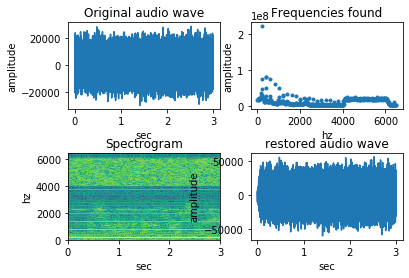

[interactive chart not shown]

For safty, I take noise within first 0.3 sec. The median filter is also applied here though the effect is not as good as that in room-speech.wav.

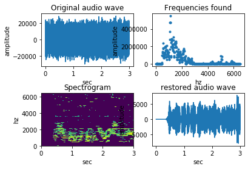

[interactive chart not shown]

Then we test wind-speech.wav similarly.

```
16000 165402 10.337625
```

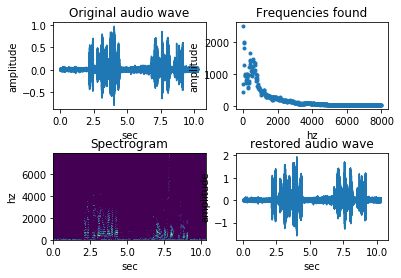

[interactive chart not shown]

Take the first 2 sec for noise sampling. I had trouble in wavfile.write. First, it seems wavfile takes int16 for the data format and I have to amplify the signal about 10000 to hear clear sound.

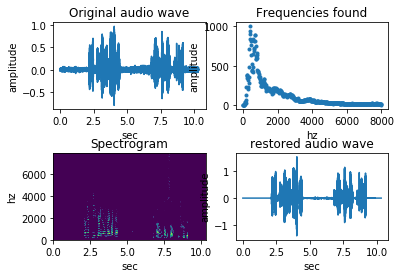

[interactive chart not shown]

Compare the denoising effect from the 3 wav files, I think room-speech.wav has the most remarkable result. I think this can be infered from the signal before and after denoising process, as well as the spectrogram. The difference is the most remarkable. Also, it can be somehow predicted since the noise of room-speech.wav is most regular and separated from the voice (compared to the other two files).

### Part 2. Implement a Voice Activity Detector (VAD)

For the last sound we have an evolving noise profile, which causes problems since our noise description from the first two seconds isn’t accurate throughout. Because we’re lazy we want to automatically update the noise model and not to select it manually. To do so we need a VAD that lets us know when to gather noise statistics and when to denoise. Do the following:

- Take the square of the input waveform and lowpass filter it (a lot) to get an energy level over time
  - Experiment with the cutoff frequency so that you get a smooth energy-looking function
- Set a threshold over which we seem to have speech in the input
- Implement a real-time spectral subtraction denoiser
  - If an input frame is under threshold, it is noise
  - Keep track of the last few noise frames and their average amplitude will be your noise spectrum
  - If an input is over the threshold it is speech
  - Once you encounter speech perform spectral subtraction with the current noise estimate